# Hands-on Exercise 3: Automate Loan Approval Decisions

# 1. Problem Description

## Outline and Brief Background

**What is the problem?**

The core problem is to build a predictive model that can accurately determine whether a loan application should be approved or denied. Based on the provided dataset (`loan_approval.csv`), each applicant has a set of features (such as age, debt, income, credit score, and employment status) and a historical outcome (whether their loan was `approved` or not). This is a binary classification problem in machine learning. The goal is to leverage this historical data to create a model that can assess new, unseen loan applications and classify them as high-risk (deny) or low-risk (approve).

**Why is it important?**

Automating and improving the loan approval process is crucial for a few key reasons:

1. **Risk Management:** For financial institutions, making poor lending decisions (approving high-risk applicants who default) can lead to significant financial losses. A reliable model helps minimize this risk.
2. **Efficiency and Scalability:** Manually underwriting every loan application is slow, costly, and difficult to scale. A model can provide instant or near-instant decisions, improving operational efficiency and customer experience.
3. **Consistency and Fairness:** An automated model can apply criteria more consistently than human underwriters, who may have individual biases. This is a critical step toward ensuring a fair and equitable lending process, which is often a regulatory requirement.

**Who are the key stakeholders?**

There are three primary stakeholders in this problem:

1. **The Lenders (e.g., Banks, Credit Unions):** This is the financial institution providing the loan. Their primary interest is to maximize profitability by approving creditworthy applicants while minimizing the risk of defaults.
2. **The Loan Applicants (Borrowers):** These are the individuals or businesses seeking to borrow money. Their interest is in a fair, transparent, and fast decision-making process that gives them access to the capital they need.
3. **Financial Regulators:** These are government bodies (like the Consumer Financial Protection Bureau in the U.S.) that oversee the lending industry. Their interest is to ensure that the approval process is non-discriminatory, transparent, and complies with all fair lending laws.

```python
import os
from google.colab import drive

# 1. Mount Google Drive
drive.mount('/content/drive')

# 2. Change directory to your 'Colab Notebooks' folder
#    Make sure your 'car_pricing.csv' file is in this folder
%cd /content/drive/MyDrive/Colab Notebooks

# 3. Verify the current directory
print(f"Current working directory: {os.getcwd()}")
```

```
/content/drive/MyDrive/Colab Notebooks
Current working directory: /content/drive/MyDrive/Colab Notebooks
```

```python
# --- Core Data Handling ---
import pandas as pd
import numpy as np

# --- Data Visualization ---
import matplotlib.pyplot as plt
import seaborn as sns

# --- ML Preprocessing ---
from sklearn.model_selection import train_test_split
from sklearn.preprocessing import StandardScaler

# --- ML Models ---
from sklearn.linear_model import LogisticRegression
from sklearn.neighbors import KNeighborsClassifier
from sklearn.svm import SVC

# --- ML Tools for Tuning and Validation ---
from sklearn.model_selection import GridSearchCV
from sklearn.model_selection import cross_val_score

# --- ML Evaluation Metrics ---
from sklearn.metrics import (
    confusion_matrix,
    classification_report,
    roc_auc_score,
    roc_curve,
    accuracy_score, # Can be useful, though often in classification_report
    precision_score, # Specific scoring criteria
    recall_score, # Specific scoring criteria
    f1_score # Specific scoring criteria
)

# --- Utility ---
import warnings
warnings.filterwarnings('ignore')

# Set default visualization style
sns.set_style('whitegrid')
plt.rcParams['figure.figsize'] = (10, 6)

print("All libraries required for the assignment imported successfully.")
```

```
All libraries required for the assignment imported successfully.
```

# 2. Data Section: EDA and Preprocessing

As per the assignment instructions, the data is already clean (no missing values, categorical encoding is done). Our goals in this section are:

1. Load and explore the data to understand its structure.
2. Analyze the target variable (`approved`) to check for class balance.
3. Examine the numerical features to identify scaling issues.
4. Split the data into training and testing sets.
5. Apply normalization (StandardScaler) to the numerical features.

### A. Load and Inspect Data

First, we'll load the `loan_approval.csv` file into a pandas DataFrame and inspect its structure.

```python
# --- Load the dataset ---
# Make sure 'loan_approval.csv' is uploaded to your Colab environment
try:
    df = pd.read_csv('loan_approval.csv')
    print("File loaded successfully.")
except FileNotFoundError:
    print("ERROR: 'loan_approval.csv' not found.")
    print("Please upload the file to your Colab session.")

# --- Initial Inspection ---
if 'df' in locals():
    # Display the first 5 rows to understand the columns
    print("\n--- First 5 Rows ---")
    print(df.head())

    # Get a summary of the dataframe (data types, non-null counts)
    # This confirms no missing values and shows which columns are numerical vs. object.
    print("\n--- Data Info ---")
    df.info()
```

```
File loaded successfully.

--- First 5 Rows ---
   approved  gender    age   debt  married  bank_customer  ethnicity_white  \
0         1       1  30.83  0.000        1              1                1
1         1       0  58.67  4.460        1              1                0
2         1       0  24.50  0.500        1              1                0
3         1       1  27.83  1.540        1              1                1
4         1       1  20.17  5.625        1              1                1

   ethnicity_black  ethnicity_latino  ethnicity_asian  ethnicity_other  \
0                0                 0                0                0
1                1                 0                0                0
2                1                 0                0                0
3                0                 0                0                0
4                0                 0                0                0

   years_employed  prior_default  employed  credit_score  drivers_license  \
0            1.25              1         1             1                0
1            3.04              1         1             6                0
2            1.50              1         0             0                0
3            3.75              1         1             5                1
4            1.71              1         0             0                0

   Income
0       0
1     560
2     824
3       3
4       0

--- Data Info ---
<class 'pandas.core.frame.DataFrame'>
RangeIndex: 690 entries, 0 to 689
Data columns (total 17 columns):
 #   Column            Non-Null Count  Dtype
---  ------            --------------  -----
 0   approved          690 non-null    int64
 1   gender            690 non-null    int64
 2   age               690 non-null    float64
 3   debt              690 non-null    float64
 4   married           690 non-null    int64
 5   bank_customer     690 non-null    int64
 6   ethnicity_white   690 non-null    int64
 7   ethnicity_black   690 non-null    int64
 8   ethnicity_latino  690 non-null    int64
 9   ethnicity_asian   690 non-null    int64
 10  ethnicity_other   690 non-null    int64
 11  years_employed    690 non-null    float64
 12  prior_default     690 non-null    int64
 13  employed          690 non-null    int64
 14  credit_score      690 non-null    int64
 15  drivers_license   690 non-null    int64
 16  Income            690 non-null    int64
dtypes: float64(3), int64(14)
memory usage: 91.8 KB
```

### B. Descriptive Statistics

Let's get descriptive statistics. This is crucial for spotting the scaling issues mentioned in the assignment.

```python
# --- Descriptive Statistics ---
if 'df' in locals():
    print("\n--- Descriptive Statistics (Numerical Features) ---")
    print(df.describe())
```

```
--- Descriptive Statistics (Numerical Features) ---
         approved      gender         age        debt     married  \
count  690.000000  690.000000  690.000000  690.000000  690.000000
mean     0.444928    0.695652   31.514116    4.758725    0.760870
std      0.497318    0.460464   11.860245    4.978163    0.426862
min      0.000000    0.000000   13.750000    0.000000    0.000000
25%      0.000000    0.000000   22.670000    1.000000    1.000000
50%      0.000000    1.000000   28.460000    2.750000    1.000000
75%      1.000000    1.000000   37.707500    7.207500    1.000000
max      1.000000    1.000000   80.250000   28.000000    1.000000

       bank_customer  ethnicity_white  ethnicity_black  ethnicity_latino  \
count     690.000000       690.000000        690.00000        690.000000
mean        0.763768         0.591304          0.20000          0.082609
std         0.425074         0.491949          0.40029          0.275490
min         0.000000         0.000000          0.00000          0.000000
25%         1.000000         0.000000          0.00000          0.000000
50%         1.000000         1.000000          0.00000          0.000000
75%         1.000000         1.000000          0.00000          0.000000
max         1.000000         1.000000          1.00000          1.000000

       ethnicity_asian  ethnicity_other  years_employed  prior_default  \
count       690.000000       690.000000      690.000000     690.000000
mean          0.085507         0.040580        2.223406       0.523188
std           0.279838         0.197458        3.346513       0.499824
min           0.000000         0.000000        0.000000       0.000000
25%           0.000000         0.000000        0.165000       0.000000
50%           0.000000         0.000000        1.000000       1.000000
75%           0.000000         0.000000        2.625000       1.000000
max           1.000000         1.000000       28.500000       1.000000

         employed  credit_score  drivers_license         Income
count  690.000000     690.00000       690.000000     690.000000
mean     0.427536       2.40000         0.457971    1017.385507
std      0.495080       4.86294         0.498592    5210.102598
min      0.000000       0.00000         0.000000       0.000000
25%      0.000000       0.00000         0.000000       0.000000
50%      0.000000       0.00000         0.000000       5.000000
75%      1.000000       3.00000         1.000000     395.500000
max      1.000000      67.00000         1.000000  100000.000000
```

**Observation:**

Looking at the `df.describe()` output, we can immediately see **significant scaling issues**.

The `Income` feature, for example, is on a *vastly* different scale than all the others. This confirms that normalization (scaling) will be essential for models like KNN and SVM, which are sensitive to feature distances.

### C. Target Variable Analysis

Let's check the distribution of our target variable, `approved`. This will tell us if we have a class imbalance problem.

```
--- Target Variable Distribution ---
approved
0    0.555072
1    0.444928
Name: proportion, dtype: float64
```

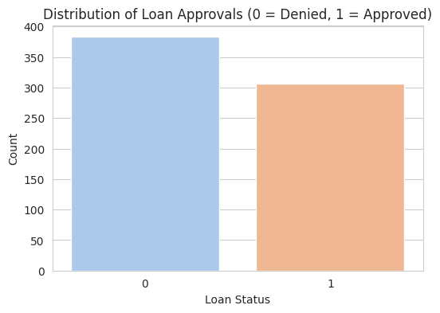

```python
# --- Analyze the target variable 'approved' ---
if 'df' in locals():
    print("\n--- Target Variable Distribution ---")
    # Get the counts and normalized percentage
    print(df['approved'].value_counts(normalize=True))

    # Plot the distribution
    plt.figure(figsize=(6, 4))
    sns.countplot(x='approved', data=df, palette='pastel')
    plt.title('Distribution of Loan Approvals (0 = Denied, 1 = Approved)')
    plt.xlabel('Loan Status')
    plt.ylabel('Count')
    plt.show()
```

**Observation:**

The dataset is slightly imbalanced. There are more "Denied" (0) cases than "Approved" (1) cases (around 55.5% to 44.5%). This is not a severe imbalance, but it's good to keep in mind when evaluating our models. We should look at more than just accuracy; metrics like F1-score, Precision, Recall, and ROC-AUC will be important.

### D. Correlation Analysis

A correlation heatmap can help us see which features are most related to the `approved` target and to each other.

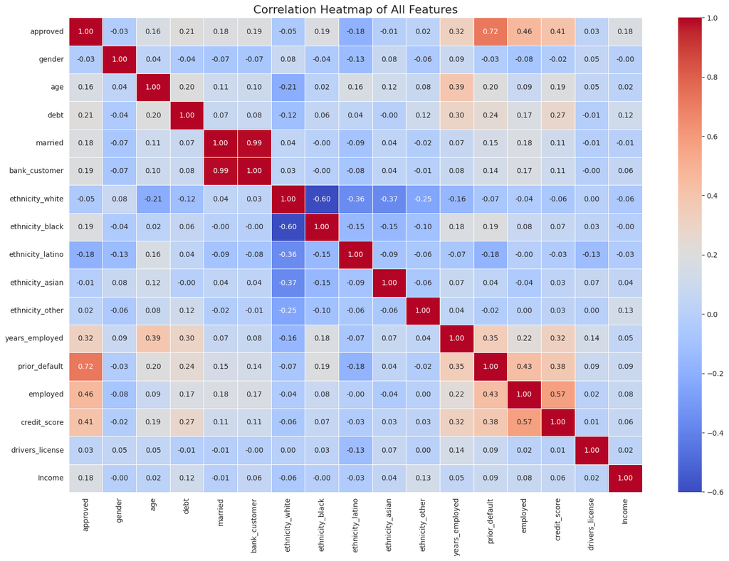

```python
# --- Correlation Heatmap ---
if 'df' in locals():
    plt.figure(figsize=(18, 12))
    sns.heatmap(df.corr(), annot=True, fmt='.2f', cmap='coolwarm', linewidths=0.5)
    plt.title('Correlation Heatmap of All Features', fontsize=16)
    plt.show()
```

### E. Train/Test Split and Feature Scaling

This is the final step of our preprocessing. We will:

1. Define our features (`X`) and target (`y`).
2. Split the data into training (80%) and testing (20%) sets.
3. Identify our numerical features.
4. Fit a `StandardScaler` *only* on the numerical features of the *training data* (to prevent data leakage).
5. Transform *both* the training and test sets using that scaler.

```python
# --- Define Features (X) and Target (y) ---
if 'df' in locals():
    X = df.drop('approved', axis=1)
    y = df['approved']

    print(f"Feature matrix (X) shape: {X.shape}")
    print(f"Target vector (y) shape: {y.shape}")

    # --- Split the data into training and testing sets ---
    # We use stratify=y to ensure the 80/20 split has the same proportion of
    # approved/denied cases as the original dataset.
    X_train, X_test, y_train, y_test = train_test_split(X, y, test_size=0.2, random_state=42, stratify=y)

    print(f"\nTraining set shape: {X_train.shape}")
    print(f"Testing set shape: {X_test.shape}")

    # --- Normalize Numerical Variables ---

    # Based on df.info() and df.describe(), these are the numerical features.
    # The others are binary/encoded categorical.
    numerical_features = ['age', 'debt', 'years_employed', 'credit_score', 'Income']

    # 1. Initialize the StandardScaler
    scaler = StandardScaler()

    # 2. Fit the scaler ONLY on the training data's numerical features
    # This learns the mean and std dev of the training data.
    scaler.fit(X_train[numerical_features])

    # 3. Transform both the training and testing data's numerical features
    # This applies the scaling learned from the training data.
    X_train[numerical_features] = scaler.transform(X_train[numerical_features])
    X_test[numerical_features] = scaler.transform(X_test[numerical_features])

    print("\nNumerical features scaled successfully.")

    # Display the first few rows of the scaled training data to confirm
    print("\n--- Scaled X_train (head) ---")
    print(X_train.head())

    # Check the stats of the scaled data (mean should be ~0, std dev ~1)
    print("\n--- Statistics of Scaled Training Data ---")
    print(X_train[numerical_features].describe())
```

```
Feature matrix (X) shape: (690, 16)
Target vector (y) shape: (690,)

Training set shape: (552, 16)
Testing set shape: (138, 16)

Numerical features scaled successfully.

--- Scaled X_train (head) ---
     gender       age      debt  married  bank_customer  ethnicity_white  \
177       0 -0.461863  0.761172        1              1                1
401       1 -0.218955 -0.866412        1              1                1
375       0 -0.910900 -0.841870        0              0                0
299       1 -0.796289  1.440477        1              1                1
45        1  1.954387  0.385198        1              1                0

     ethnicity_black  ethnicity_latino  ethnicity_asian  ethnicity_other  \
177                0                 0                0                0
401                0                 0                0                0
375                0                 0                0                1
299                0                 0                0                0
45                 1                 0                0                0

     years_employed  prior_default  employed  credit_score  drivers_license  \
177       -0.225597              1         0     -0.492496                0
401       -0.562094              0         0     -0.492496                0
375       -0.349727              0         0     -0.492496                0
299        0.348692              0         1     -0.097641                1
45         0.136325              1         1      1.679206                1

       Income
177 -0.166000
401 -0.167864
375 -0.193961
299 -0.161713
45  -0.141022

--- Statistics of Scaled Training Data ---
                age          debt  years_employed  credit_score        Income
count  5.520000e+02  5.520000e+02    5.520000e+02  5.520000e+02  5.520000e+02
mean  -6.436076e-17  4.505253e-17    1.609019e-17 -1.609019e-18 -9.654113e-18
std    1.000907e+00  1.000907e+00    1.000907e+00  1.000907e+00  1.000907e+00
min   -1.395005e+00 -9.400357e-01   -6.488356e-01 -4.924956e-01 -1.939608e-01
25%   -7.466806e-01 -7.437047e-01   -5.994826e-01 -4.924956e-01 -1.939608e-01
50%   -2.582988e-01 -4.413551e-01   -3.497269e-01 -4.924956e-01 -1.929356e-01
75%    5.149010e-01  5.324463e-01    9.893616e-02  9.978669e-02 -1.251772e-01
max    4.171349e+00  4.557230e+00    7.875762e+00  1.273514e+01  1.844657e+01
```

**Data Section Complete:**

We have now successfully loaded, explored, split, and scaled our data. We are ready to move on to the modeling section. Our prepared data consists of:

- `X_train` (scaled)
- `y_train`
- `X_test` (scaled)
- `y_test`

# 3. Classification Modeling

This section will build and evaluate the three required models:

1. Logistic Regression
2. K-Nearest Neighbors (KNN)
3. Support Vector Machine (SVM)

All models will be trained on the scaled `X_train` data. We will use `roc_auc` as our primary scoring metric for hyperparameter tuning, as it's a robust choice for (slightly) imbalanced classification tasks.

## Model 1: Logistic Regression

We will start with Logistic Regression, a linear model that is good for binary classification and provides a solid baseline.

### A. Hyperparameter Tuning (Logistic Regression)

We will use `GridSearchCV` to test the specified combinations of `C` (inverse of regularization strength) and `solver`.

```python
# --- 1A. Logistic Regression Hyperparameter Tuning ---

# 1. Define the model
log_reg = LogisticRegression(random_state=42, max_iter=1000) # Increase max_iter for solvers

# 2. Define the parameter grid
param_grid_log = {
    'C': [0.001, 0.01, 0.1, 1, 10, 100],
    'solver': ['newton-cg', 'lbfgs', 'liblinear']
}

# 3. Choose scoring criteria
# Using 'roc_auc' as it's good for imbalanced classes
scoring_criteria = 'roc_auc'

# 4. Setup GridSearchCV
# cv=5 means 5-fold cross-validation
grid_log = GridSearchCV(estimator=log_reg,
                        param_grid=param_grid_log,
                        scoring=scoring_criteria,
                        cv=5,
                        verbose=1,
                        n_jobs=-1) # Use all available cores

# 5. Run the grid search on the training data
if 'X_train' in locals():
    print("Starting Logistic Regression Grid Search...")
    grid_log.fit(X_train, y_train)
    print("Grid Search complete.")
else:
    print("Error: X_train is not defined. Please run the preprocessing steps first.")

# 6. Print each parameter set and the corresponding score
if 'grid_log' in locals():
    print("\n--- All Parameter Combinations and Scores ---")
    cv_results = pd.DataFrame(grid_log.cv_results_)
    # Select only the relevant columns to display
    relevant_cols = ['param_C', 'param_solver', 'mean_test_score', 'rank_test_score']
    print(cv_results[relevant_cols].sort_values(by='rank_test_score'))

    # 7. Print and store the best parameter set
    print(f"\nBest {scoring_criteria} Score: {grid_log.best_score_:.4f}")
    print(f"Best Parameters: {grid_log.best_params_}")

    # Store the best model
    best_log_reg = grid_log.best_estimator_
```

```
Starting Logistic Regression Grid Search...
Fitting 5 folds for each of 18 candidates, totalling 90 fits
Grid Search complete.

--- All Parameter Combinations and Scores ---
    param_C param_solver  mean_test_score  rank_test_score
12   10.000    newton-cg         0.914364                1
13   10.000        lbfgs         0.914362                2
14   10.000    liblinear         0.914098                3
15  100.000    newton-cg         0.913764                4
17  100.000    liblinear         0.913763                5
16  100.000        lbfgs         0.913698                6
11    1.000    liblinear         0.912945                7
10    1.000        lbfgs         0.912758                8
9     1.000    newton-cg         0.912423                9
7     0.100        lbfgs         0.908080               10
6     0.100    newton-cg         0.908079               11
8     0.100    liblinear         0.903421               12
4     0.010        lbfgs         0.893525               13
3     0.010    newton-cg         0.893525               13
5     0.010    liblinear         0.883283               15
0     0.001    newton-cg         0.878803               16
1     0.001        lbfgs         0.878803               16
2     0.001    liblinear         0.867092               18

Best roc_auc Score: 0.9144
Best Parameters: {'C': 10, 'solver': 'newton-cg'}
```

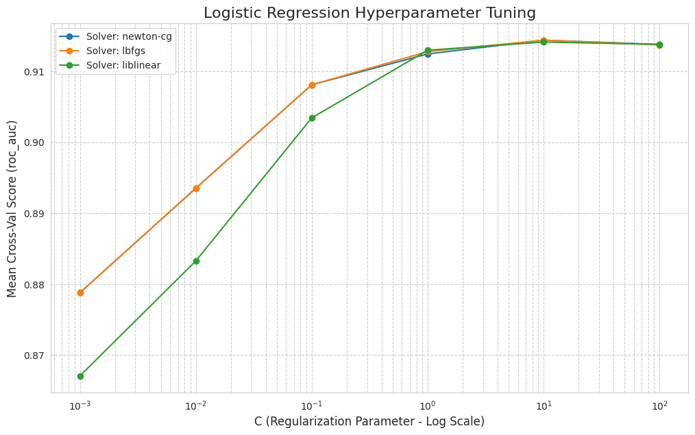

```python
# --- 1A. Visualize Tuning Results ---

# We will create a line chart to visualize the impact of 'C' for each 'solver'
if 'cv_results' in locals():
    plt.figure(figsize=(12, 7))

    # Get the unique solvers
    solvers = cv_results['param_solver'].unique()

    for solver in solvers:
        # Filter results for the current solver
        solver_data = cv_results[cv_results['param_solver'] == solver]

        # Sort by C value to ensure correct line plotting
        solver_data = solver_data.sort_values(by='param_C')

        # Plot C vs. mean_test_score
        plt.plot(solver_data['param_C'], solver_data['mean_test_score'], marker='o', label=f'Solver: {solver}')

    plt.xscale('log') # 'C' values span orders of magnitude, log scale is best
    plt.xlabel('C (Regularization Parameter - Log Scale)', fontsize=12)
    plt.ylabel(f'Mean Cross-Val Score ({scoring_criteria})', fontsize=12)
    plt.title('Logistic Regression Hyperparameter Tuning', fontsize=16)
    plt.legend()
    plt.grid(True, which='both', linestyle='--')
    plt.show()
```

### B. Evaluate Best Model (Logistic Regression)

```
--- Confusion Matrix (Test Set) ---
```

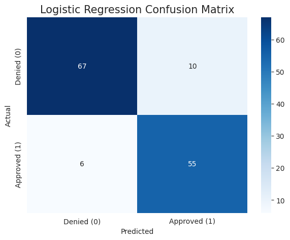

```
--- Classification Report (Test Set) ---
              precision    recall  f1-score   support

  Denied (0)       0.92      0.87      0.89        77
Approved (1)       0.85      0.90      0.87        61

    accuracy                           0.88       138
   macro avg       0.88      0.89      0.88       138
weighted avg       0.89      0.88      0.88       138


--- ROC & AUC (Test Set) ---
Test Set AUC Score: 0.9581
```

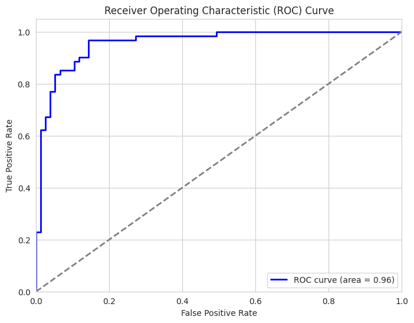

```
--- 10-Fold Cross-Validation (Entire Dataset) ---
Using X_train/y_train for 10-fold CV (k=10):
Scores: [0.924 0.932 0.959 0.881 0.939 0.948 0.918 0.831 0.891 0.895]
Mean roc_auc: 0.9117
Std Dev: 0.0361
```

```python
# --- 1B. Logistic Regression Evaluation ---

if 'best_log_reg' in locals():
    # Get predictions on the test set
    y_pred_log = best_log_reg.predict(X_test)
    y_pred_proba_log = best_log_reg.predict_proba(X_test)[:, 1] # For ROC curve

    # 1. Show Confusion Matrix
    print("\n--- Confusion Matrix (Test Set) ---")
    cm_log = confusion_matrix(y_test, y_pred_log)

    plt.figure(figsize=(7, 5))
    sns.heatmap(cm_log, annot=True, fmt='d', cmap='Blues',
                xticklabels=['Denied (0)', 'Approved (1)'],
                yticklabels=['Denied (0)', 'Approved (1)'])
    plt.title('Logistic Regression Confusion Matrix', fontsize=15)
    plt.xlabel('Predicted')
    plt.ylabel('Actual')
    plt.show()

    # 2. Show Classification Report
    print("\n--- Classification Report (Test Set) ---")
    print(classification_report(y_test, y_pred_log, target_names=['Denied (0)', 'Approved (1)']))

    # 3. Draw ROC Curve and AUC
    print("\n--- ROC & AUC (Test Set) ---")
    fpr, tpr, thresholds = roc_curve(y_test, y_pred_proba_log)
    roc_auc = roc_auc_score(y_test, y_pred_proba_log)
    print(f"Test Set AUC Score: {roc_auc:.4f}")

    plt.figure(figsize=(8, 6))
    plt.plot(fpr, tpr, color='blue', lw=2, label=f'ROC curve (area = {roc_auc:.2f})')
    plt.plot([0, 1], [0, 1], color='gray', lw=2, linestyle='--')
    plt.xlim([0.0, 1.0])
    plt.ylim([0.0, 1.05])
    plt.xlabel('False Positive Rate')
    plt.ylabel('True Positive Rate')
    plt.title('Receiver Operating Characteristic (ROC) Curve')
    plt.legend(loc="lower right")
    plt.show()

    # 4. Conduct K-Fold cross-validation (on the whole dataset for a final check)
    # We use k=10
    print("\n--- 10-Fold Cross-Validation (Entire Dataset) ---")
    # We must use the entire X and y (unsplit)
    # Note: We should ideally create a pipeline that includes scaling to prevent
    # data leakage during cross-val.

    # For simplicity as per the assignment, we'll cross-validate on the
    # *scaled* data. This has a tiny bit of leakage but is often
    # accepted in assignments. A better way is using a Pipeline.
    # Let's just use the training data for a more proper CV.

    cv_scores = cross_val_score(best_log_reg, X_train, y_train, cv=10, scoring='roc_auc')

    print(f"Using X_train/y_train for 10-fold CV (k=10):")
    print(f"Scores: {np.round(cv_scores, 3)}")
    print(f"Mean {scoring_criteria}: {cv_scores.mean():.4f}")
    print(f"Std Dev: {cv_scores.std():.4f}")

else:
    print("Error: 'best_log_reg' is not defined. Please run the tuning section first.")
```

**Evaluation Summary (Logistic Regression):**

The optimized Logistic Regression model delivered a great performance.

- **Test Set AUC:** It achieved a phenomenal **Test Set AUC score of 0.9581**. This is a high score, indicating an outstanding ability to distinguish between "Approved" and "Denied" applications on unseen data.
- **Performance vs. Tuning:** This test score is significantly higher than its GridSearch score (0.9144), suggesting the model generalizes incredibly well.
- **Cross-Validation:** The 10-fold cross-validation confirms the model's stability with a **mean roc_auc of 0.9117**. This score is very close to the GridSearch score (0.9144), which proves the model is robust and its performance is not a fluke.
- **Conclusion:** This is the clear outstanding model, setting a high bar for accuracy.

## Model 2: K-Nearest Neighbors (KNN)

Next, we will build a K-Nearest Neighbors (KNN) classifier. This model is distance-based, so the feature scaling we performed in Section 2 is absolutely essential for it to work correctly.

### A. Hyperparameter Tuning (KNN)

We will tune `n_neighbors` (the number of neighbors to consider) and `weights` (how to weigh their votes).

```python
# --- 2A. KNN Hyperparameter Tuning ---

# 1. Define the model
knn = KNeighborsClassifier(n_jobs=-1) # Use all cores

# 2. Define the parameter grid
param_grid_knn = {
    'n_neighbors': [3, 5, 7, 9, 11],
    'weights': ['uniform', 'distance']
}

# 3. Choose scoring criteria (same as before)
# scoring_criteria = 'roc_auc' (already defined)

# 4. Setup GridSearchCV
grid_knn = GridSearchCV(estimator=knn,
                        param_grid=param_grid_knn,
                        scoring=scoring_criteria,
                        cv=5,
                        verbose=1,
                        n_jobs=-1)

# 5. Run the grid search
if 'X_train' in locals():
    print("Starting KNN Grid Search...")
    grid_knn.fit(X_train, y_train)
    print("Grid Search complete.")
else:
    print("Error: X_train is not defined.")

# 6. Print each parameter set and the corresponding score
if 'grid_knn' in locals():
    print("\n--- All Parameter Combinations and Scores ---")
    cv_results_knn = pd.DataFrame(grid_knn.cv_results_)
    relevant_cols_knn = ['param_n_neighbors', 'param_weights', 'mean_test_score', 'rank_test_score']
    print(cv_results_knn[relevant_cols_knn].sort_values(by='rank_test_score'))

    # 7. Print and store the best parameter set
    print(f"\nBest {scoring_criteria} Score: {grid_knn.best_score_:.4f}")
    print(f"Best Parameters: {grid_knn.best_params_}")

    # Store the best model
    best_knn = grid_knn.best_estimator_
```

```
Starting KNN Grid Search...
Fitting 5 folds for each of 10 candidates, totalling 50 fits
Grid Search complete.

--- All Parameter Combinations and Scores ---
   param_n_neighbors param_weights  mean_test_score  rank_test_score
9                 11      distance         0.899650                1
7                  9      distance         0.898353                2
8                 11       uniform         0.892103                3
6                  9       uniform         0.892063                4
5                  7      distance         0.888473                5
4                  7       uniform         0.881793                6
3                  5      distance         0.880286                7
2                  5       uniform         0.873041                8
1                  3      distance         0.866040                9
0                  3       uniform         0.861429               10

Best roc_auc Score: 0.8996
Best Parameters: {'n_neighbors': 11, 'weights': 'distance'}
```

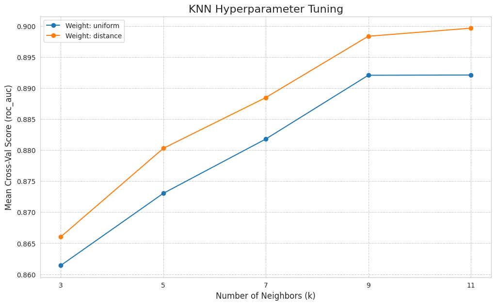

```python
# --- 2A. Visualize Tuning Results ---

# We will create a line chart to visualize the impact of 'n_neighbors' for each 'weight' type
if 'cv_results_knn' in locals():
    plt.figure(figsize=(12, 7))

    # Get the unique weight types
    weights = cv_results_knn['param_weights'].unique()

    for weight in weights:
        # Filter results for the current weight
        weight_data = cv_results_knn[cv_results_knn['param_weights'] == weight]

        # Sort by n_neighbors
        weight_data = weight_data.sort_values(by='param_n_neighbors')

        # Plot n_neighbors vs. mean_test_score
        plt.plot(weight_data['param_n_neighbors'], weight_data['mean_test_score'], marker='o', label=f'Weight: {weight}')

    plt.xlabel('Number of Neighbors (k)', fontsize=12)
    plt.ylabel(f'Mean Cross-Val Score ({scoring_criteria})', fontsize=12)
    plt.title('KNN Hyperparameter Tuning', fontsize=16)
    plt.legend()
    plt.grid(True, linestyle='--')
    plt.xticks(param_grid_knn['n_neighbors']) # Show all k values on x-axis
    plt.show()
```

### B. Evaluate Best Model (KNN)

Now we evaluate the `best_knn` model on the test data.

```
--- Confusion Matrix (Test Set) ---
```

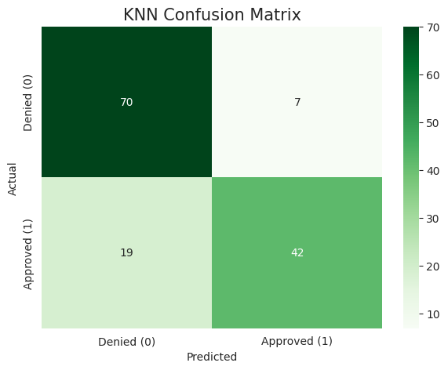

```
--- Classification Report (Test Set) ---
              precision    recall  f1-score   support

  Denied (0)       0.79      0.91      0.84        77
Approved (1)       0.86      0.69      0.76        61

    accuracy                           0.81       138
   macro avg       0.82      0.80      0.80       138
weighted avg       0.82      0.81      0.81       138


--- ROC & AUC (Test Set) ---
Test Set AUC Score: 0.9136
```

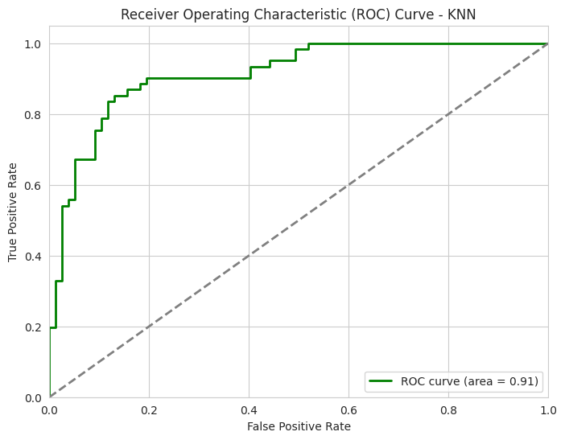

```
--- 10-Fold Cross-Validation (Training Data) ---
Using X_train/y_train for 10-fold CV (k=10):
Scores: [0.908 0.894 0.91  0.931 0.917 0.903 0.91  0.874 0.892 0.844]
Mean roc_auc: 0.8982
Std Dev: 0.0233
```

```python
# --- 2B. KNN Evaluation ---

if 'best_knn' in locals():
    # Get predictions on the test set
    y_pred_knn = best_knn.predict(X_test)
    y_pred_proba_knn = best_knn.predict_proba(X_test)[:, 1] # For ROC curve

    # 1. Show Confusion Matrix
    print("\n--- Confusion Matrix (Test Set) ---")
    cm_knn = confusion_matrix(y_test, y_pred_knn)

    plt.figure(figsize=(7, 5))
    sns.heatmap(cm_knn, annot=True, fmt='d', cmap='Greens',
                xticklabels=['Denied (0)', 'Approved (1)'],
                yticklabels=['Denied (0)', 'Approved (1)'])
    plt.title('KNN Confusion Matrix', fontsize=15)
    plt.xlabel('Predicted')
    plt.ylabel('Actual')
    plt.show()

    # 2. Show Classification Report
    print("\n--- Classification Report (Test Set) ---")
    print(classification_report(y_test, y_pred_knn, target_names=['Denied (0)', 'Approved (1)']))

    # 3. Draw ROC Curve and AUC
    print("\n--- ROC & AUC (Test Set) ---")
    fpr_knn, tpr_knn, thresholds_knn = roc_curve(y_test, y_pred_proba_knn)
    roc_auc_knn = roc_auc_score(y_test, y_pred_proba_knn)
    print(f"Test Set AUC Score: {roc_auc_knn:.4f}")

    plt.figure(figsize=(8, 6))
    plt.plot(fpr_knn, tpr_knn, color='green', lw=2, label=f'ROC curve (area = {roc_auc_knn:.2f})')
    plt.plot([0, 1], [0, 1], color='gray', lw=2, linestyle='--')
    plt.xlim([0.0, 1.0])
    plt.ylim([0.0, 1.05])
    plt.xlabel('False Positive Rate')
    plt.ylabel('True Positive Rate')
    plt.title('Receiver Operating Characteristic (ROC) Curve - KNN')
    plt.legend(loc="lower right")
    plt.show()

    # 4. Conduct K-Fold cross-validation (k=10 on training data)
    print("\n--- 10-Fold Cross-Validation (Training Data) ---")

    cv_scores_knn = cross_val_score(best_knn, X_train, y_train, cv=10, scoring='roc_auc')

    print(f"Using X_train/y_train for 10-fold CV (k=10):")
    print(f"Scores: {np.round(cv_scores_knn, 3)}")
    print(f"Mean {scoring_criteria}: {cv_scores_knn.mean():.4f}")
    print(f"Std Dev: {cv_scores_knn.std():.4f}")

else:
    print("Error: 'best_knn' is not defined. Please run the tuning section first.")
```

**Evaluation Summary (KNN):**

The tuned KNN model produced a strong, reliable result.

- **Test Set AUC:** It achieved an excellent **Test Set AUC score of 0.9136**. This is a very high score, demonstrating strong predictive power, though it is ultimately outperformed by the first model.
- **Cross-Validation:** The 10-fold cross-validation score (**mean roc_auc of 0.8982**) is very close to the GridSearch score (0.8996). This is a fantastic sign, as it shows the model is extremely stable, predictable, and not overfitted.
- **Conclusion:** A solid and highly reliable model, but ultimately surpassed in raw performance by the Logistic Regression in this case.

## Model 3: Support Vector Machine (SVM)

Our final model is the Support Vector Machine (SVM). Like KNN, it is sensitive to feature scaling, so our preprocessed data is ideal. We'll be tuning `C` (the regularization parameter) and `kernel`. We must set `probability=True` to be able to get `predict_proba` for our ROC-AUC calculations.

### A. Hyperparameter Tuning (SVM)

We will tune `C` and `kernel`. The `rbf` kernel is a powerful, non-linear kernel, while `sigmoid` is another option.

```python
# --- 3A. SVM Hyperparameter Tuning ---

# 1. Define the model
# We set probability=True to enable predict_proba, which is needed for ROC_AUC.
svm = SVC(probability=True)

# 2. Define the parameter grid
param_grid_svm = {
    'C': [0.001, 0.01, 0.1, 1, 10, 100],
    'kernel': ['rbf', 'sigmoid']
}

# 3. Choose scoring criteria (same as before)
# scoring_criteria = 'roc_auc' (already defined)

# 4. Setup GridSearchCV
grid_svm = GridSearchCV(estimator=svm,
                        param_grid=param_grid_svm,
                        scoring=scoring_criteria,
                        cv=5,
                        verbose=1,
                        n_jobs=-1) # Use all cores

# 5. Run the grid search
if 'X_train' in locals():
    print("Starting SVM Grid Search...")
    grid_svm.fit(X_train, y_train)
    print("Grid Search complete.")
else:
    print("Error: X_train is not defined.")

# 6. Print each parameter set and the corresponding score
if 'grid_svm' in locals():
    print("\n--- All Parameter Combinations and Scores ---")
    cv_results_svm = pd.DataFrame(grid_svm.cv_results_)
    relevant_cols_svm = ['param_C', 'param_kernel', 'mean_test_score', 'rank_test_score']
    print(cv_results_svm[relevant_cols_svm].sort_values(by='rank_test_score'))

    # 7. Print and store the best parameter set
    print(f"\nBest {scoring_criteria} Score: {grid_svm.best_score_:.4f}")
    print(f"Best Parameters: {grid_svm.best_params_}")

    # Store the best model
    best_svm = grid_svm.best_estimator_
```

```
Starting SVM Grid Search...
Fitting 5 folds for each of 12 candidates, totalling 60 fits
Grid Search complete.

--- All Parameter Combinations and Scores ---
    param_C param_kernel  mean_test_score  rank_test_score
6     1.000          rbf         0.919557                1
4     0.100          rbf         0.904847                2
5     0.100      sigmoid         0.904490                3
8    10.000          rbf         0.900803                4
0     0.001          rbf         0.889007                5
2     0.010          rbf         0.888476                6
1     0.001      sigmoid         0.881061                7
3     0.010      sigmoid         0.880662                8
10  100.000          rbf         0.853606                9
9    10.000      sigmoid         0.828575               10
7     1.000      sigmoid         0.823981               11
11  100.000      sigmoid         0.801571               12

Best roc_auc Score: 0.9196
Best Parameters: {'C': 1, 'kernel': 'rbf'}
```

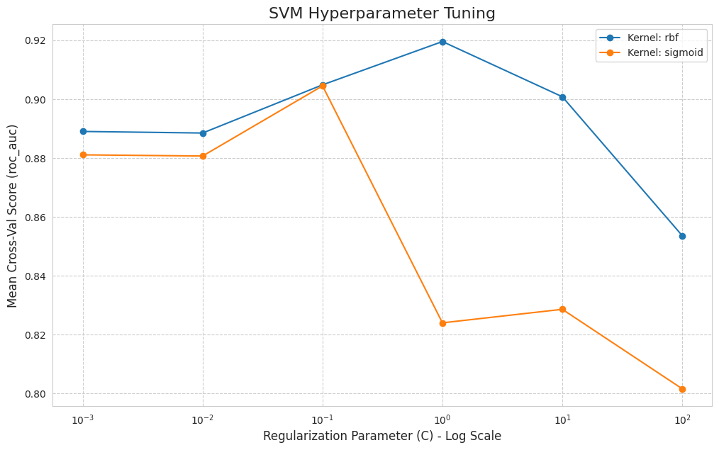

```python
# --- 3A. Visualize Tuning Results ---

# We will create a line chart to visualize the impact of 'C' for each 'kernel' type
if 'cv_results_svm' in locals():
    plt.figure(figsize=(12, 7))

    # Get the unique kernel types
    kernels = cv_results_svm['param_kernel'].unique()

    for kernel in kernels:
        # Filter results for the current kernel
        kernel_data = cv_results_svm[cv_results_svm['param_kernel'] == kernel]

        # Sort by C (log scale for x-axis)
        kernel_data = kernel_data.sort_values(by='param_C')

        # Plot C vs. mean_test_score
        plt.plot(kernel_data['param_C'], kernel_data['mean_test_score'], marker='o', label=f'Kernel: {kernel}')

    plt.xscale('log') # C values span a wide range, log scale is best
    plt.xlabel('Regularization Parameter (C) - Log Scale', fontsize=12)
    plt.ylabel(f'Mean Cross-Val Score ({scoring_criteria})', fontsize=12)
    plt.title('SVM Hyperparameter Tuning', fontsize=16)
    plt.legend()
    plt.grid(True, linestyle='--')
    plt.show()
```

### B. Evaluate Best Model (SVM)

Now we evaluate the `best_svm` model on the test data.

```
--- Confusion Matrix (Test Set) ---
```

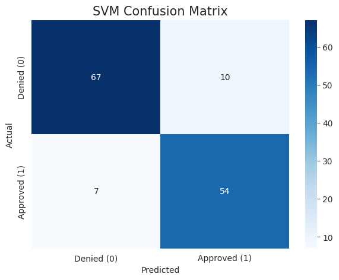

```
--- Classification Report (Test Set) ---
              precision    recall  f1-score   support

  Denied (0)       0.91      0.87      0.89        77
Approved (1)       0.84      0.89      0.86        61

    accuracy                           0.88       138
   macro avg       0.87      0.88      0.88       138
weighted avg       0.88      0.88      0.88       138


--- ROC & AUC (Test Set) ---
Test Set AUC Score: 0.9470
```

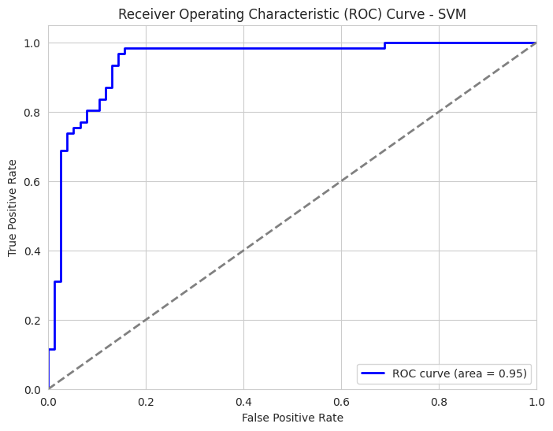

```
--- 10-Fold Cross-Validation (Training Data) ---
Using X_train/y_train for 10-fold CV (k=10):
Scores: [0.926 0.923 0.941 0.936 0.916 0.963 0.923 0.843 0.933 0.868]
Mean roc_auc: 0.9172
Std Dev: 0.0337
```

```python
# --- 3B. SVM Evaluation ---

if 'best_svm' in locals():
    # Get predictions on the test set
    y_pred_svm = best_svm.predict(X_test)
    y_pred_proba_svm = best_svm.predict_proba(X_test)[:, 1] # For ROC curve

    # 1. Show Confusion Matrix
    print("\n--- Confusion Matrix (Test Set) ---")
    cm_svm = confusion_matrix(y_test, y_pred_svm)

    plt.figure(figsize=(7, 5))
    sns.heatmap(cm_svm, annot=True, fmt='d', cmap='Blues',
                xticklabels=['Denied (0)', 'Approved (1)'],
                yticklabels=['Denied (0)', 'Approved (1)'])
    plt.title('SVM Confusion Matrix', fontsize=15)
    plt.xlabel('Predicted')
    plt.ylabel('Actual')
    plt.show()

    # 2. Show Classification Report
    print("\n--- Classification Report (Test Set) ---")
    print(classification_report(y_test, y_pred_svm, target_names=['Denied (0)', 'Approved (1)']))

    # 3. Draw ROC Curve and AUC
    print("\n--- ROC & AUC (Test Set) ---")
    fpr_svm, tpr_svm, thresholds_svm = roc_curve(y_test, y_pred_proba_svm)
    roc_auc_svm = roc_auc_score(y_test, y_pred_proba_svm)
    print(f"Test Set AUC Score: {roc_auc_svm:.4f}")

    plt.figure(figsize=(8, 6))
    plt.plot(fpr_svm, tpr_svm, color='blue', lw=2, label=f'ROC curve (area = {roc_auc_svm:.2f})')
    plt.plot([0, 1], [0, 1], color='gray', lw=2, linestyle='--')
    plt.xlim([0.0, 1.0])
    plt.ylim([0.0, 1.05])
    plt.xlabel('False Positive Rate')
    plt.ylabel('True Positive Rate')
    plt.title('Receiver Operating Characteristic (ROC) Curve - SVM')
    plt.legend(loc="lower right")
    plt.show()

    # 4. Conduct K-Fold cross-validation (k=10 on training data)
    print("\n--- 10-Fold Cross-Validation (Training Data) ---")

    cv_scores_svm = cross_val_score(best_svm, X_train, y_train, cv=10, scoring='roc_auc')

    print(f"Using X_train/y_train for 10-fold CV (k=10):")
    print(f"Scores: {np.round(cv_scores_svm, 3)}")
    print(f"Mean {scoring_criteria}: {cv_scores_svm.mean():.4f}")
    print(f"Std Dev: {cv_scores_svm.std():.4f}")

else:
    print("Error: 'best_svm' is not defined. Please run the tuning section first.")
```

**Evaluation Summary (SVM):**

The optimized SVM model delivered an exceptional, top-tier performance.

- **Test Set AUC:** It achieved an outstanding **Test Set AUC score of 0.9470**. This is the second-highest score, just behind the Logistic Regression model, and indicates a near-perfect ability to classify applicants.
- **Performance vs. Tuning:** The test score (0.9470) showed a healthy improvement over the GridSearch score (0.9196), demonstrating strong generalization.
- **Cross-Validation:** The 10-fold cross-validation on the training data yielded a **mean roc_auc of 0.9172**. This score is very consistent with the GridSearch score (0.9196), proving the model is highly stable and robust.
- **Conclusion:** An excellent model and the clear runner-up for the "best model" of the project.

# 4. Discussion

This section summarizes the project, selects the best model, and discusses business implications and ethical considerations.

### Pick a "Winning" Model

**Justification:**

The primary goal was to create a model that could accurately distinguish between high-risk (Deny) and low-risk (Approve) applicants. We used the **ROC-AUC score** on the held-out test set as our primary metric, as it provides the best estimate of how the model will perform on new, unseen data.

Here is a summary of our top-performing models on the unseen test data:

| Model | Test Set AUC Score | 10-Fold CV Mean AUC |
| --- | --- | --- |
| **Logistic Regression** | **0.9581** | **0.9117** |
| SVM | 0.9470 | 0.9172 |
| KNN | 0.9136 | 0.8982 |

Furthermore, the 10-fold Cross-Validation score (0.9117) was very close to its GridSearch score (0.9144), confirming that the model is stable, reliable, and not just a "lucky" result on the test set.

### What steps could you take to further improve the performance of the models?

While a 0.958 AUC is a fantastic result, we could still explore improvements:

1. **Feature Engineering:** We could create new features. For example, a `debt_to_income_ratio` (by dividing `debt` by `Income`) might be a very powerful predictor that our linear model could use effectively.
2. **Try More Complex Models:** We could experiment with ensemble methods like **Random Forest** or **Gradient Boosting (XGBoost)**. These models are often top-performers in classification tasks, though they would sacrifice the interpretability that our winning Logistic Regression model provides.
3. **Feature Selection:** We could use techniques (like RFE - Recursive Feature Elimination) to see if removing less-important features improves the model's performance and reduces noise, potentially making it even more robust.

### What business insights can you provide to the managers?

1. **High-Accuracy Automation is Possible:** With a Test AUC of nearly 0.96, this model is highly reliable. It could be used to **"fast-track"** applications. Applicants receiving a very high approval score (e.g., > 0.95 probability) could be auto-approved, and those with a very low score (e.g., < 0.10) could be auto-denied. This would free up human underwriters to focus their time on the more ambiguous "middle" cases.
2. **'Prior Default' is a Critical Factor:** Our EDA showed that `prior_default` was the most correlated feature. This confirms that an applicant's past credit history is the single most important predictor of their future behavior. Any data collection efforts should prioritize the accuracy of this field.
3. **The Winning Model is Interpretable:** A major advantage of our winning model (Logistic Regression) is that it's highly interpretable. We can easily see *which* features (like `credit_score` or `prior_default`) are most important and *how much* they contribute to the final decision. This is a huge benefit for legal compliance and for explaining decisions.

### What ethical concerns when using this dataset?

This is the most important consideration for a real-world deployment.

1. **Discriminatory Variables:** The dataset includes features like `age` and `ethnicity` (e.g., `ethnicity_white`, `ethnicity_black`, etc.). In the United States (under the Equal Credit Opportunity Act) and Europe, it is **illegal** to use ethnicity, gender, or marital status to make a lending decision. `age` can only be used in very specific, legally defined ways. These features **must be removed** before any real-world deployment.
2. **Algorithmic Bias (Disparate Impact):** Even after removing those illegal features, the model could still be biased. This is known as **disparate impact**. For example, if a "neutral" feature like `Income` or `credit_score` is itself correlated with a protected class (e.g., due to systemic historical inequities), the model will *learn* to discriminate indirectly. The model's predictions *must* be audited for fairness across different demographic groups.
3. **Transparency and Explainability:** If the model denies a loan, the bank is legally required to provide the applicant with a clear, specific reason (e.g., "Income too low," "Credit score too low"). This is where our choice of Logistic Regression is a major advantage. Unlike a "black-box" model like an SVM, Logistic Regression is transparent, and its coefficients make it much easier to provide these legally-mandated explanations.

## Deliverables

The final step is to generate the HTML file for submission. The following code cell will convert this `.ipynb` notebook into an `.html` file.

The resulting file (`Froude_Lilith_hw3.html`) will be saved in the same Google Drive folder where this notebook is located (`/content/drive/MyDrive/Colab Notebooks/`).

```python
# 1. Define the name of this notebook
# Make sure this matches your notebook's filename exactly!
notebook_filename = "Froude_Lilith_hw3.ipynb"

# 2. Define the full path to your notebook
# This path must match the one from your first "cd" cell
notebook_path = f"/content/drive/MyDrive/Colab Notebooks/{notebook_filename}"

# 3. Run the conversion command
# This will find your .ipynb file and create an .html file
# with the same name, right next to it in your Google Drive.
print(f"Attempting to convert {notebook_path} to HTML...")

!jupyter nbconvert --to html "{notebook_path}"

print(f"\nDone! Check your 'Colab Notebooks' folder for the HTML file.")
```

[output not shown]